# Introduction

The purpose of machine learning is often to create a model that explains some real-world data, so that we can predict what may happen next, with different outputs.

The simplest model that we can fit data to is a line. When we are trying to find a line that fits a set of data best, we are performing *Linear Regression*.

A line is a rough approximation, but it allows us the ability to explain and predict variables that have a linear relationship with each other.

## Points and Lines

A line is determined by its slope and its intercept. In other words, for each point `y` on a line we can say:

$y = mx + b$

where `m` is the slope, and `b` is the intercept. `y` is a given point on the y-axis, and it corresponds to a given `x` on the x-axis.

The slope is a measure of how steep the line is, while the intercept is a measure of where the line hits the y-axis.

When we perform Linear Regression, the goal is to get the "best" `m` and `b` for our data.

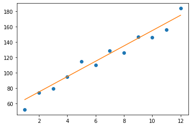

```python
import matplotlib.pyplot as plt

months = [1, 2, 3, 4, 5, 6, 7, 8, 9, 10, 11, 12]
revenue = [52, 74, 79, 95, 115, 110, 129, 126, 147, 146, 156, 184]

# slope
m = 10

# intercept
b = 55

y = [(month * m) + b for month in months]

plt.plot(months, revenue, 'o')
plt.plot(months, y)
plt.show()
```

## Loss

When we think about how we can assign a slope and intercept to fit a set of points, we have to define what the best fit is.

For each data point, we calculate loss, a number that measures how bad the model's prediction was.

We can think about loss as the squared distance from the point to the line. We do the squared distance so that points above and below the line both contribute to total loss in the same way.

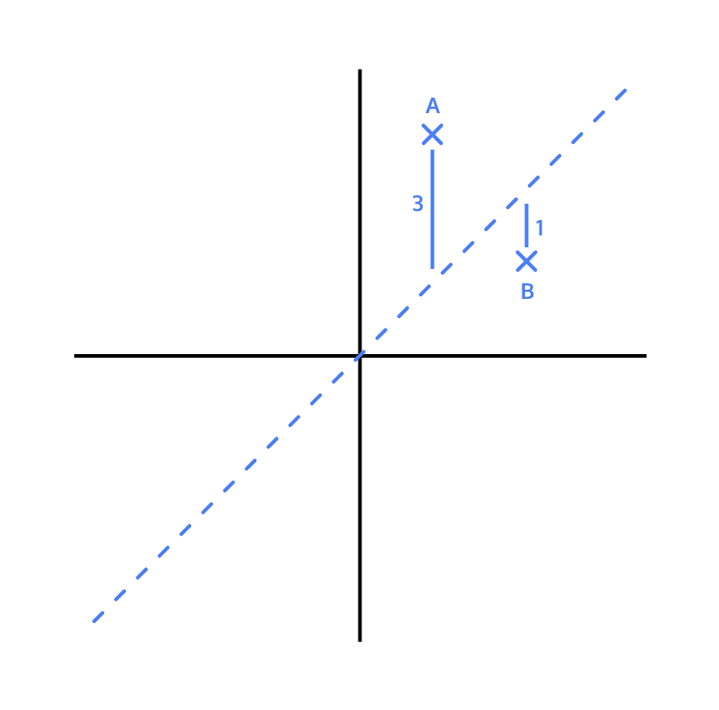

For point A, the squared distance is 9.\ For point B, the squared distance is 1.

So the total loss, with this model, is 10. If we found a line that had less loss than 10, that line would be a better model for this data.

```python
x = [1, 2, 3]
y = [5, 1, 3]

# y = x
m1 = 1
b1 = 0

# y = 0.5x + 1
m2 = 0.5
b2 = 1

y_predicted1 = [(element * m1) + b1 for element in x]
y_predicted2 = [(element * m2) + b2 for element in x]

total_loss1 = 0
for i in range(len(y)):
    total_loss1 += (y[i] - y_predicted1[i]) ** 2

total_loss2 = 0
for i in range(len(y)):
    total_loss2 += (y[i] - y_predicted2[i]) ** 2

print(total_loss1)
print(total_loss2)
```

```
17
13.5
```

## Minimizing Loss

The goal of a linear regression model is to find the slope and intercept pair that minimizes loss on average across all of the data.

## Gradient Descent for Intercept

As we try to minimize loss, we take each parameter we are changing, and move it as long as we are decreasing loss. It's like we are moving down a hill, and stop once we reach the bottom.

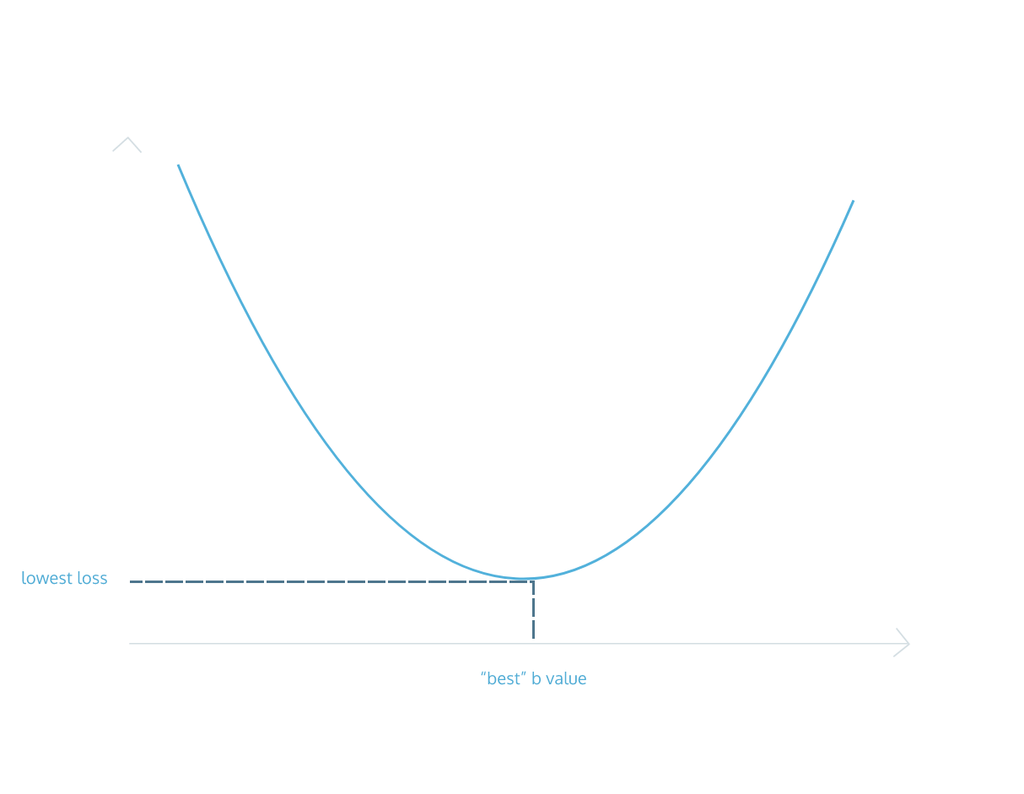

The process by which we do this is called *gradient descent*. We move in the direction that decreases our loss the most. *Gradient* refers to the slope of the curve at any point.

To find the gradient of loss as intercept changes, the formula comes out to be:

$\frac{2}{N}\sum_{i=1}^{N}-(y_i-(mx_i+b))$

where `N` is the number of points we have in our dataset,\ `m` is the current gradient guess,\ `b` is the current intercept guess

```python
def get_gradient_at_b(x, y, m, b):
    diff = 0
    N = len(x)
    for i in range(0, len(x)):
        y_val = y[i]
        x_val = x[i]
        diff += (y_val - ((m * x_val) + b))
    b_gradient = (-2/N) * diff
    return b_gradient

x = [1, 2, 3, 4]
y = [4, 6, 8, 10]

print(get_gradient_at_b(x, y, 2, 2))
```

```
-0.0
```

## Gradient Descent for Slope

To find the m gradient, or the way the loss changes as the slope of our line changes, we can use this formula:

$\frac{2}{N}\sum_{i=1}^{N}-x_i(y_i-(mx_i+b))$

```python
def get_gradient_at_m(x, y, m, b):
    diff = 0
    N = len(x)
    for i in range(N):
        y_val = y[i]
        x_val = x[i]
        diff += (x_val * (y_val - (m * x_val + b)))
    m_gradient = (-2/N) * diff
    return m_gradient

x = [1, 2, 3, 4]
y = [4, 6, 8, 10]

print(get_gradient_at_m(x, y, 2, 2))
```

```
-0.0
```

Now that we know how to calculate the gradient, we want to take a step in that direction. However, it's important to think about whether that step is too big or too small.

We can scale the size of the step by multiplying the gradient by a *learning rate.*

```python
def step_gradient(x, y, b_current, m_current):
    b_gradient = get_gradient_at_b(x, y, m_current, b_current, )
    m_gradient = get_gradient_at_m(x, y, m_current, b_current, )
    b = b_current - (0.01 * b_gradient)
    m = m_current - (0.01 * m_gradient)
    return b, m

months = [1, 2, 3, 4, 5, 6, 7, 8, 9, 10, 11, 12]
revenue = [52, 74, 79, 95, 115, 110, 129, 126, 147, 146, 156, 184]

# current intercept guess:
b = 0
# current slope guess:
m = 0

# call step function here to update b and m
b, m = step_gradient(months, revenue, b, m)
print(b, m)
```

```
2.355 17.78333333333333
```

## Convergence

How do we know when our program has learned enough?

To answer this, we have to define convergence. **Convergence** is when the loss stops changing (or changes very slowly) when parameters are changed.

## Learning Rate

We want our program to be able to iteratively learn what the best m and b values are. So for each m and b pair that we guess, we want to move them in the direction of the gradients we've calculated. But how far do we move in that direction?

We have to choose a *learning rate*, which will determine how far down the loss curve we go.

A small learning rate will take a long time to converge. A large learning rate might skip over the best value. It might never converge!

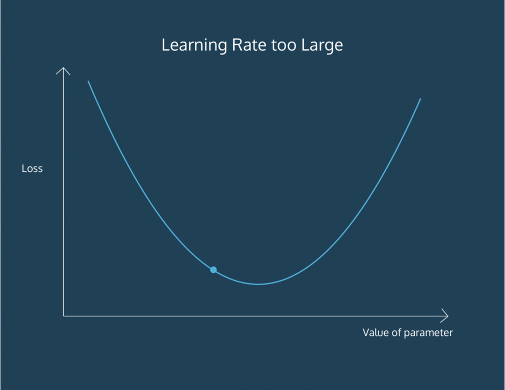

Finding the absolute best learning rate is not necessary for training a model. You just have to find a learning rate large enough that gradient descent converges with the efficiency you need, and not so large that convergence never happens.

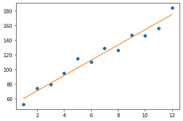

```python
def get_gradient_at_b(x, y, b, m):
    diff = 0
    N = len(x)
    for i in range(0, len(x)):
        y_val = y[i]
        x_val = x[i]
        diff += (y_val - ((m * x_val) + b))
    b_gradient = (-2/N) * diff
    return b_gradient

def get_gradient_at_m(x, y, b, m):
    diff = 0
    N = len(x)
    for i in range(N):
        y_val = y[i]
        x_val = x[i]
        diff += (x_val * (y_val - (m * x_val + b)))
    m_gradient = (-2/N) * diff
    return m_gradient

def step_gradient(b_current, m_current, x, y, learning_rate):
    b_gradient = get_gradient_at_b(x, y, b_current, m_current)
    m_gradient = get_gradient_at_m(x, y, b_current, m_current)
    b = b_current - (learning_rate * b_gradient)
    m = m_current - (learning_rate * m_gradient)
    return b, m


def gradient_descent(x, y, learning_rate, num_iterations):
    b = 0
    m = 0
    for i in range(num_iterations):
        b, m = step_gradient(b, m, x, y, learning_rate)
    return b, m

months = [1, 2, 3, 4, 5, 6, 7, 8, 9, 10, 11, 12]
revenue = [52, 74, 79, 95, 115, 110, 129, 126, 147, 146, 156, 184]

b, m = gradient_descent(months, revenue, 0.01, 1000)

y = [m*x + b for x in months]

plt.plot(months, revenue, "o")
plt.plot(months, y)

plt.show()
```

## Use Functions on Real Data

Let's try what we've constructed on the set of baseball players' heights and weights.

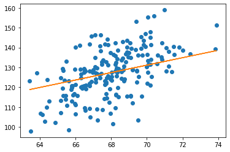

```python
from gradient_descent_funcs import gradient_descent
import pandas as pd
import matplotlib.pyplot as plt

df = pd.read_csv('heights.csv')

x = df['height']
y = df['weight']

b,m = gradient_descent(x, y, 0.0001, 1000)

y_predictions = [((element * m) + b) for element in x]

plt.plot(x, y, 'o')
plt.plot(x, y_predictions)
plt.show()
```

## Scikit-Learn

Luckily, we don't have to build a linear regression algorithm from scratch every time we want to use it. We can use Python's scikit-learn library.

Scikit-learn, or `sklearn`, is used specifically for Machine Learning. Inside the `linear_model` module, there is a `LinearRegression()` function we can use:

`from sklearn.linear_model import LinearRegression`

You can first create a `LinearRegression` model, and then fit it to your x and y data:

`line_fitter = LinearRegression()`\ `line_fitter.fit(x, y)`

The `.fit()` method gives the model two variables that are useful to us:

- the `line_fitter.coef_`, which contains the slope
- the `line_fitter.intercept_`, which contains the intercept

We can also use the `.predict()` function to pass in x-values and receive the y-values that this line would predict:

`y_predicted = line_fitter.predict(x)`

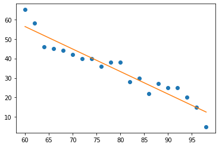

```python
from sklearn.linear_model import LinearRegression
import matplotlib.pyplot as plt
import numpy as np

temperature = np.array(range(60, 100, 2))
temperature = temperature.reshape(-1, 1)
sales = [65, 58, 46, 45, 44, 42, 40, 40, 36, 38, 38, 28, 30, 22, 27, 25, 25, 20, 15, 5]

line_fitter = LinearRegression()
line_fitter.fit(temperature, sales)

sales_predict = line_fitter.predict(temperature)
plt.plot(temperature, sales, 'o')
plt.plot(temperature, sales_predict)
plt.show()
```

## Review

We have seen how to implement a linear regression algorithm in Python, and how to use the linear regression model from scikit-learn:

- We can measure how well a line fits by measuring loss
- The goal of linear regression is to minimize loss
- To find the line of best fit, we try to find the `b` value (intercept) and the `m` value (slope) that minimize loss
- *Convergence* refers to when the parameters stop changing with each iteration
- *Learning rate* refers to how much the parameters are changed on each iteration
- We can use Scikit-learn `LinearRegression()` model to perform linear regression on a set of points.

These are important tools to have in your data science toolkit!